# Análisis de Campañas de Marketing

Métodos de Simulación Estadística - Maestría en Ciencia de Datos - Pontificia Universidad Javeriana Cali

Victor Hugo Perilla Martinez

2026-02-20

# 1 Índice

1. Índice
2. Descripción
3. Objetivos
4. Datos
5. Procesamiento
6. Resultados y discusión
7. Conclusiones
8. Referencias
9. Anexos

# 2 Descripción

Este trabajo tiene como propósito la realización de un análisis estadístico completo de la información recolectada de campañas piloto de marketing en una compañía, con el fin de entender las diferentes características, comportamientos de compras de los clientes y perfiles sociodemográficos de estos. Para esto, se hará un proceso de preparación y exploración de datos que incluye varios pasos, como los son: la limpieza de la información y el tratamiento de valores atípicos mediante eliminación o imputación, posteriormente el análisis de la información descriptiva de los datos mediante el uso de la estadística y el uso de representaciones gráficas.

Se busca con estos pasos lograr una buena calidad en los datos siendo consistentes y confiables para el desarrollo de futuros modelos, esto permitiendo interpretar con fundamentos las diferencias entre clientes que aceptaron o no las ofertas en las diferentes campañas realizadas por la compañía. Los resultados obtenidos serán un insumo clave para la segmentación de clientes y la optimización de la rentabilidad en campañas de marketing a futuro. El informe dará un sustento basado en los hallazgos sobre los datos y que en combinación con el contexto darán claridad y conocimiento sobre los clientes que se tienen para la comercialización del nuevo dispositivo.

# 3 Objetivos

## 3.1 Objetivo general

Desarrollar un análisis estadístico integral de la base de datos de clientes que hacen parte de la campaña piloto, esto mediante el procesamiento de datos teniendo en cuanta la limpieza, tratamiento de valores atípicos, imputación de datos faltantes y análisis descriptivo, para lograr caracterizar y distinguir los diferentes perfiles de clientes que aceptaron y no aceptaron la oferta, encontrando información relevante para la construcción de un modelo predictivo de rentabilidad para la próxima campaña de marketing.

## 3.2 Objetivos específicos

- Identificar y depurar inconsistencias en la base de datos, incluyendo registros duplicados, errores de codificación y valores atípicos, garantizando la calidad e integridad de la información utilizada en el análisis.
- Analizar y darles tratamiento a los datos faltantes, verificando su mecanismo de generación (MCAR u otro) y aplicando las medidas de eliminación o imputación adecuadas que preserven la estructura del conjunto de datos
- Realizar la descripción estadística de las variables presentes en el conjunto de datos, si son útiles y necesarias, esto se hará mediante indicadores de tendencia central, dispersión, posición y representaciones gráficas que permitan el entendimiento de la distribución de la variable y el comportamiento de los clientes.
- Realizar la comparación y diferenciación de las múltiples características de los clientes que aceptaron y no aceptaron la oferta en la última campaña, analizando los diferentes patrones de consumo, variables sociodemográficas, comportamientos de compra, y datos pasados de otras campañas que generen información útil para la segmentación.
- Seleccionar y consolidar hallazgos del análisis, presentando los resultados de una forma clara y concisa, con los fundamentados que respaldan la toma de decisiones en el procesamiento de los datos para su uso en modelos que permitan hacer predicciones en las futuras campañas de marketing.

# 4 Datos

La base de datos es una muestra de un piloto realizado a clientes, se usará para analizar la aceptación de un nuevo producto en campañas de marketing. Contiene información sociodemográfica, económica y de comportamiento de compra, como edad, ingresos, estado civil, educación, gastos en productos, frecuencia de compras y respuesta a campañas anteriores.

Incluye variables cuantitativas y cualitativas, así como indicadores binarios de aceptación o rechazo de ofertas. La Tabla 4.1 presenta la descripción y la clasificación de cada variable de acuerdo con su naturaleza.:

```r
tabla1 <- data.frame( "Nombre" = c( "Income","Kidhome","Teenhome","Recency","MntWines","MntFruits", "MntMeatProducts","MntFishProducts","MntSweetProducts","MntGoldProds", "NumDealsPurchases","NumWebPurchases","NumCatalogPurchases","NumStorePurchases", "NumWebVisitsMonth","AcceptedCmp3","AcceptedCmp4","AcceptedCmp5", "AcceptedCmp1","AcceptedCmp2","Complain","Response","Age", "Customer_Days","marital_Divorced","marital_Married","marital_Single", "marital_Together","marital_Widow","education_2n Cycle","education_Basic", "education_Graduation","education_Master","education_PhD","MntTotal", "MntRegularProds","AcceptedCmpOverall" ),

"Descripción" = c( "Ingreso anual del hogar del cliente", "Número de niños pequeños en el hogar", "Número de adolescentes en el hogar", "Días desde la última compra", "Gasto en vinos", "Gasto en frutas", "Gasto en carnes", "Gasto en pescado", "Gasto en dulces", "Gasto en productos de oro, productos premium", "Número de compras con descuento", "Número de compras por web", "Número de compras por catálogo", "Número de compras en tienda física", "Número de visitas web en el último mes", "Aceptó campaña 3 (1=Sí, 0=No)", "Aceptó campaña 4 (1=Sí, 0=No)", "Aceptó campaña 5 (1=Sí, 0=No)", "Aceptó campaña 1 (1=Sí, 0=No)", "Aceptó campaña 2 (1=Sí, 0=No)", "Presentó queja", "Aceptó la última campaña", "Edad del cliente", "Días desde que es cliente", "Estado civil divorciado (Binaria - Posible One-Hot Encoding)", "Estado civil casado (Binaria - Posible One-Hot Encoding)", "Estado civil soltero (Binaria - Posible One-Hot Encoding)", "Estado civil en pareja (Binaria - Posible One-Hot Encoding)", "Estado civil viudo (Binaria - Posible One-Hot Encoding)", "Educación secundaria", "Educación básica", "Educación universitaria", "Educación maestría", "Educación doctorado", "Gasto total en todos los productos", "Gasto total en productos regulares que no son premium", "Número total de campañas aceptadas" ),

"Clasificación por naturaleza" = c( "Cuantitativa Continua", "Cuantitativa Discreta", "Cuantitativa Discreta", "Cuantitativa Discreta", "Cuantitativa Continua", "Cuantitativa Continua", "Cuantitativa Continua", "Cuantitativa Continua", "Cuantitativa Continua", "Cuantitativa Continua", "Cuantitativa Discreta", "Cuantitativa Discreta", "Cuantitativa Discreta", "Cuantitativa Discreta", "Cuantitativa Discreta", "Cualitativa Nominal (Dato Binario)", "Cualitativa Nominal (Dato Binario)", "Cualitativa Nominal (Dato Binario)", "Cualitativa Nominal (Dato Binario)", "Cualitativa Nominal (Dato Binario)", "Cualitativa Nominal (Dato Binario)", "Cualitativa Nominal (Dato Binario)", "Cuantitativa Discreta", "Cuantitativa Discreta", "Cualitativa Nominal (Dato Binario)", "Cualitativa Nominal (Dato Binario)", "Cualitativa Nominal (Dato Binario)", "Cualitativa Nominal (Dato Binario)", "Cualitativa Nominal (Dato Binario)", "Cualitativa Ordinal", "Cualitativa Ordinal", "Cualitativa Ordinal", "Cualitativa Ordinal", "Cualitativa Ordinal", "Cuantitativa Continua", "Cuantitativa Continua", "Cuantitativa Discreta" ),

stringsAsFactors = FALSE,
check.names = FALSE)

diccionario_vars <- c(

  # Demográficas y económicas
  "Income" = "Ingreso anual del hogar (Income)",
  "Age" = "Edad del cliente (Age)",
  "Kidhome" = "Número de niños en el hogar (Kidhome)",
  "Teenhome" = "Número de adolescentes en el hogar (Teenhome)",
  "Customer_Days" = "Antigüedad como cliente en días (Customer_Days)",

  # Estado civil
  "marital_Divorced" = "Estado civil: Divorciado (marital_Divorced)",
  "marital_Married" = "Estado civil: Casado (marital_Married)",
  "marital_Single" = "Estado civil: Soltero (marital_Single)",
  "marital_Together" = "Estado civil: Unión libre (marital_Together)",
  "marital_Widow" = "Estado civil: Viudo (marital_Widow)",

  # Educación
  "education_2n Cycle" = "Nivel educativo: Ciclo técnico (education_2n Cycle)",
  "education_Basic" = "Nivel educativo: Básico (education_Basic)",
  "education_Graduation" = "Nivel educativo: Profesional (education_Graduation)",
  "education_Master" = "Nivel educativo: Maestría (education_Master)",
  "education_PhD" = "Nivel educativo: Doctorado (education_PhD)",

  # Variables monetarias
  "MntWines" = "Gasto en vinos (MntWines)",
  "MntFruits" = "Gasto en frutas (MntFruits)",
  "MntMeatProducts" = "Gasto en carnes (MntMeatProducts)",
  "MntFishProducts" = "Gasto en pescado (MntFishProducts)",
  "MntSweetProducts" = "Gasto en dulces (MntSweetProducts)",
  "MntGoldProds" = "Gasto en productos premium (MntGoldProds)",
  "MntRegularProds" = "Gasto en productos regulares (MntRegularProds)",
  "MntTotal" = "Gasto total del cliente (MntTotal)",

  # Comportamiento de compra
  "Recency" = "Días desde la última compra (Recency)",
  "NumDealsPurchases" = "Compras con descuento (NumDealsPurchases)",
  "NumWebPurchases" = "Compras por página web (NumWebPurchases)",
  "NumCatalogPurchases" = "Compras por catálogo (NumCatalogPurchases)",
  "NumStorePurchases" = "Compras en tienda física (NumStorePurchases)",
  "NumWebVisitsMonth" = "Visitas mensuales al sitio web (NumWebVisitsMonth)",

  # Campañas
  "AcceptedCmp1" = "Aceptó campaña 1 (AcceptedCmp1)",
  "AcceptedCmp2" = "Aceptó campaña 2 (AcceptedCmp2)",
  "AcceptedCmp3" = "Aceptó campaña 3 (AcceptedCmp3)",
  "AcceptedCmp4" = "Aceptó campaña 4 (AcceptedCmp4)",
  "AcceptedCmp5" = "Aceptó campaña 5 (AcceptedCmp5)",
  "AcceptedCmpOverall" = "Total de campañas aceptadas (AcceptedCmpOverall)",

  # Respuesta final y reclamos
  "Response" = "Aceptó última campaña (Response)",
  "Complain" = "Presentó reclamo (Complain)"
)


knitr::kable( tabla1, caption = "Descripción y clasificación de variables de acuerdo con su naturaleza",
             format = "html") %>%
  kable_styling(bootstrap_options = c("bordered", "striped", "hover"), full_width = F, font_size = 11)
```

Table 4.1: Descripción y clasificación de variables de acuerdo con su naturaleza

| Nombre | Descripción | Clasificación por naturaleza |
| --- | --- | --- |
| Income | Ingreso anual del hogar del cliente | Cuantitativa Continua |
| Kidhome | Número de niños pequeños en el hogar | Cuantitativa Discreta |
| Teenhome | Número de adolescentes en el hogar | Cuantitativa Discreta |
| Recency | Días desde la última compra | Cuantitativa Discreta |
| MntWines | Gasto en vinos | Cuantitativa Continua |
| MntFruits | Gasto en frutas | Cuantitativa Continua |
| MntMeatProducts | Gasto en carnes | Cuantitativa Continua |
| MntFishProducts | Gasto en pescado | Cuantitativa Continua |
| MntSweetProducts | Gasto en dulces | Cuantitativa Continua |
| MntGoldProds | Gasto en productos de oro, productos premium | Cuantitativa Continua |
| NumDealsPurchases | Número de compras con descuento | Cuantitativa Discreta |
| NumWebPurchases | Número de compras por web | Cuantitativa Discreta |
| NumCatalogPurchases | Número de compras por catálogo | Cuantitativa Discreta |
| NumStorePurchases | Número de compras en tienda física | Cuantitativa Discreta |
| NumWebVisitsMonth | Número de visitas web en el último mes | Cuantitativa Discreta |
| AcceptedCmp3 | Aceptó campaña 3 (1=Sí, 0=No) | Cualitativa Nominal (Dato Binario) |
| AcceptedCmp4 | Aceptó campaña 4 (1=Sí, 0=No) | Cualitativa Nominal (Dato Binario) |
| AcceptedCmp5 | Aceptó campaña 5 (1=Sí, 0=No) | Cualitativa Nominal (Dato Binario) |
| AcceptedCmp1 | Aceptó campaña 1 (1=Sí, 0=No) | Cualitativa Nominal (Dato Binario) |
| AcceptedCmp2 | Aceptó campaña 2 (1=Sí, 0=No) | Cualitativa Nominal (Dato Binario) |
| Complain | Presentó queja | Cualitativa Nominal (Dato Binario) |
| Response | Aceptó la última campaña | Cualitativa Nominal (Dato Binario) |
| Age | Edad del cliente | Cuantitativa Discreta |
| Customer_Days | Días desde que es cliente | Cuantitativa Discreta |
| marital_Divorced | Estado civil divorciado (Binaria - Posible One-Hot Encoding) | Cualitativa Nominal (Dato Binario) |
| marital_Married | Estado civil casado (Binaria - Posible One-Hot Encoding) | Cualitativa Nominal (Dato Binario) |
| marital_Single | Estado civil soltero (Binaria - Posible One-Hot Encoding) | Cualitativa Nominal (Dato Binario) |
| marital_Together | Estado civil en pareja (Binaria - Posible One-Hot Encoding) | Cualitativa Nominal (Dato Binario) |
| marital_Widow | Estado civil viudo (Binaria - Posible One-Hot Encoding) | Cualitativa Nominal (Dato Binario) |
| education_2n Cycle | Educación secundaria | Cualitativa Ordinal |
| education_Basic | Educación básica | Cualitativa Ordinal |
| education_Graduation | Educación universitaria | Cualitativa Ordinal |
| education_Master | Educación maestría | Cualitativa Ordinal |
| education_PhD | Educación doctorado | Cualitativa Ordinal |
| MntTotal | Gasto total en todos los productos | Cuantitativa Continua |
| MntRegularProds | Gasto total en productos regulares que no son premium | Cuantitativa Continua |
| AcceptedCmpOverall | Número total de campañas aceptadas | Cuantitativa Discreta |

# 5 Procesamiento

## 5.1 Errores e inconsistencias

### 5.1.1 Datos duplicados

```r
#Analisis de Duplicados
cant_original = nrow(datos)
conteo_duplicados = sum(duplicated(datos))
porcentaje_dup <- (conteo_duplicados / cant_original) * 100

datos_sin_duplicados <- datos[!duplicated(datos), ]

n_datos_sin_duplicados <- nrow(datos_sin_duplicados)

resumen_duplicados <- data.frame(
  Indicador = c("Registros Originales",
                 "Registros Duplicados Identificados",
                 "Porcentaje de Duplicidad (%)",
                 "Registros Únicos Finales"),
  Valor = c(cant_original,
            conteo_duplicados,
            round(porcentaje_dup, 2),
            n_datos_sin_duplicados)
)

knitr::kable( resumen_duplicados, caption = "Resumen de validación de datos duplicados",
             format = "html") %>%
  kable_styling(bootstrap_options = c("bordered", "striped", "hover"), full_width = F, font_size = 11)
```

Table 5.1: Resumen de validación de datos duplicados

| Indicador | Valor |
| --- | --- |
| Registros Originales | 2220.00 |
| Registros Duplicados Identificados | 179.00 |
| Porcentaje de Duplicidad (%) | 8.06 |
| Registros Únicos Finales | 2041.00 |

En el primer preprocesamiento de los datos, se realiza validación de duplicados, no hay un id, tomamos los registros por fila com únicos, se encontraron 2220 registros originales en los datos, pero habían 179 duplicados (8.06%). Al final con la eliminación de datos duplicados quedaron 2041 datos. Esto se puede ver en la Tabla 5.1

### 5.1.2 Inconsistencias de datos

#### 5.1.2.1 Variables de aceptación de campañas

La figura 5.1 muestra la distribución de frecuencias de la variable `AcceptedCmp1`, `AcceptedCmp2`,`AcceptedCmp3`, `AcceptedCmp4` y`AcceptedCmp5`, se observa que es binaria y que no tiene datos faltantes ni incosistentes.

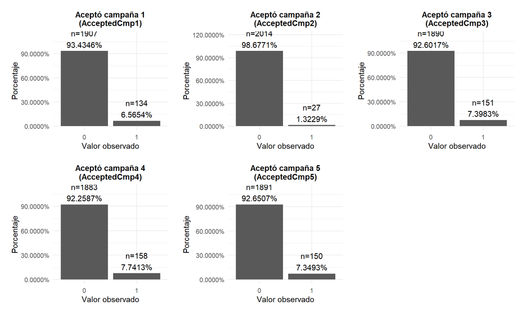

Figure 5.1: Distribución porcentual de las variables de aceptación de campañas (Binarias). Se incluyen valores faltantes como categoría explícita.

```r
vars <- c("AcceptedCmp1","AcceptedCmp2","AcceptedCmp3",
          "AcceptedCmp4","AcceptedCmp5")

data_temp <- datos_sin_duplicados

plots <- lapply(vars, function(v){

  conteo <- as.data.frame(table(data_temp[[v]], useNA = "ifany"))
  colnames(conteo) <- c("valor", "n")

  conteo$pct <- conteo$n / sum(conteo$n)

  ymax <- max(conteo$pct) * 1.20

  ggplot(conteo, aes(x = factor(valor), y = pct)) +
    geom_col() +
    geom_text(aes(label = paste0("n=", n, "\n", sprintf("%.4f%%", 100*pct))),
              vjust = -0.2, size = 3.8) +
    scale_y_continuous(labels = function(x) sprintf("%.4f%%", 100*x),
                       limits = c(0, ymax)) +
    labs(
      title = stringr::str_wrap(diccionario_vars[[v]], width = 30),
      x = "Valor observado",
      y = "Porcentaje"
    ) +
    theme_minimal() +
    theme(
      plot.title = element_text(size = 11, face = "bold", hjust = 0.5),
      plot.margin = margin(10, 10, 10, 10)
    )
})

wrap_plots(plots, ncol = 3)
```

#### 5.1.2.2 Variables de estado civil

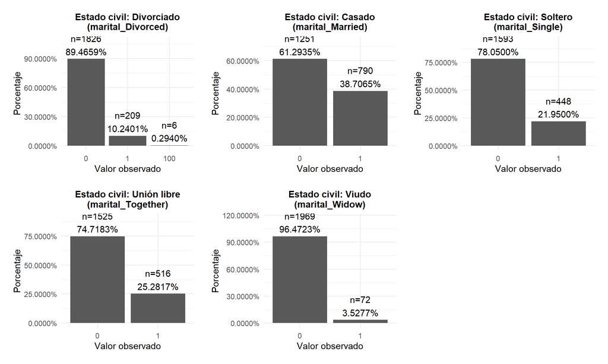

Figure 5.2: Distribución porcentual de las variables de estado civil (One-Hot Encoding). Se incluyen valores faltantes como categoría explícita.

```r
vars <- c("marital_Divorced","marital_Married","marital_Single",
          "marital_Together","marital_Widow")

data_temp <- datos_sin_duplicados

plots <- lapply(vars, function(v){

  conteo <- as.data.frame(table(data_temp[[v]], useNA = "ifany"))
  colnames(conteo) <- c("valor", "n")

  conteo$pct <- conteo$n / sum(conteo$n)

  ymax <- max(conteo$pct) * 1.20

  ggplot(conteo, aes(x = factor(valor), y = pct)) +
    geom_col() +
    geom_text(aes(label = paste0("n=", n, "\n", sprintf("%.4f%%", 100*pct))),
              vjust = -0.2, size = 3.8) +
    scale_y_continuous(labels = function(x) sprintf("%.4f%%", 100*x),
                       limits = c(0, ymax)) +
    labs(
      title = stringr::str_wrap(diccionario_vars[[v]], width = 30),
      x = "Valor observado",
      y = "Porcentaje"
    ) +
    theme_minimal() +
    theme(
      plot.title = element_text(size = 11, face = "bold", hjust = 0.5),
      plot.margin = margin(10, 10, 10, 10)
    )
})

wrap_plots(plots, ncol = 3)
```

```r
variable <- "marital_Divorced"
datos_sin_inconsistencia_v1 <- datos_sin_duplicados

n_total <- nrow(datos_sin_inconsistencia_v1)
n_anomalias <- sum(datos_sin_inconsistencia_v1[[variable]] == 100, na.rm = TRUE)
pct_anomalias <- (n_anomalias / n_total) * 100


datos_sin_inconsistencia_v1[[variable]] <- replace(
  datos_sin_duplicados[[variable]],
  datos_sin_duplicados[[variable]] == 100,
  1
)


n_anomalias_final <- sum(datos_sin_inconsistencia_v1[[variable]] == 100, na.rm = TRUE)

resumen_correccion_divorced <- data.frame(
  Indicador = c(
    "Variable analizada",
    "Registros con valor erróneo (100)",
    "Porcentaje de error (%)",
    "Valor de reemplazo aplicado",
    "Registros corregidos",
    "Inconsistencias restantes (Validación)"
  ),
  Valor = c(
    variable,
    n_anomalias,
    round(pct_anomalias, 4),
    "1",
    n_anomalias,
    n_anomalias_final
  )
)

knitr::kable( resumen_correccion_divorced, caption = "Resumen de Corrección de Error de Digitación: Estado Civil marital_Divorced",
             format = "html") %>%
  kable_styling(bootstrap_options = c("bordered", "striped", "hover"), full_width = F, font_size = 11)
```

Table 5.2: Resumen de Corrección de Error de Digitación: Estado Civil marital_Divorced

| Indicador | Valor |
| --- | --- |
| Variable analizada | marital_Divorced |
| Registros con valor erróneo (100) | 6 |
| Porcentaje de error (%) | 0.294 |
| Valor de reemplazo aplicado | 1 |
| Registros corregidos | 6 |
| Inconsistencias restantes (Validación) | 0 |

Adicionalmente se valida el grupo de variables de estado civil y se entienden como una variable categórica a la cual se le realizón codificación One-Hot-Encoding, por lo cual se valida inconsistencias de si algún registro no definido algún estado civil o si tiene más de un estado civil, para este grupo de registros no se encontraron inconsistencias de este tipo. El resumen de la validación está en la tabla 5.3

```r
data_temp <- datos_sin_inconsistencia_v1
nivel_educativo <- c("marital_Divorced", "marital_Married", "marital_Single",
                     "marital_Together", "marital_Widow")

#Identificación de inconsistencias
suma_categorias <- rowSums(data_temp[, nivel_educativo])
n_total <- nrow(data_temp)
n_inconsistentes <- sum(suma_categorias != 1)

# Imputación / Limpieza
datos_sin_inconsistencia_v2 <- data_temp[suma_categorias == 1, ]


n_final <- nrow(datos_sin_inconsistencia_v2)
n_eliminados <- n_total - n_final
pct_inconsistentes <- (n_inconsistentes / n_total) * 100
pct_final <- (n_final / n_total) * 100


resumen_estado_civil <- data.frame(
  Indicador = c(
    "Total registros analizados",
    "Registros con error (Suma != 1)",
    "Porcentaje de inconsistencia (%)",
    "Registros eliminados/imputados",
    "Registros válidos finales",
    "Porcentaje de integridad final (%)"
  ),
  Valor = c(
    n_total,
    n_inconsistentes,
    round(pct_inconsistentes, 2),
    n_eliminados,
    n_final,
    round(pct_final, 2)
  )
)

knitr::kable( resumen_estado_civil, caption = "Resumen de Validación e Imputación: Estado Civil",
             format = "html") %>%
  kable_styling(bootstrap_options = c("bordered", "striped", "hover"), full_width = F, font_size = 11)
```

Table 5.3: Resumen de Validación e Imputación: Estado Civil

| Indicador | Valor |
| --- | --- |
| Total registros analizados | 2041 |
| Registros con error (Suma != 1) | 0 |
| Porcentaje de inconsistencia (%) | 0 |
| Registros eliminados/imputados | 0 |
| Registros válidos finales | 2041 |
| Porcentaje de integridad final (%) | 100 |

#### 5.1.2.3 Variables de nivel de educación

La figura 5.3 muestra la distribución de frecuencias de la variable `education_Basic`, `education_2n Cycle`, `education_Graduation`, `education_Master` y `education_PhD`, se observa que es binaria y que no tiene datos faltantes. No hay datos inconsistente.

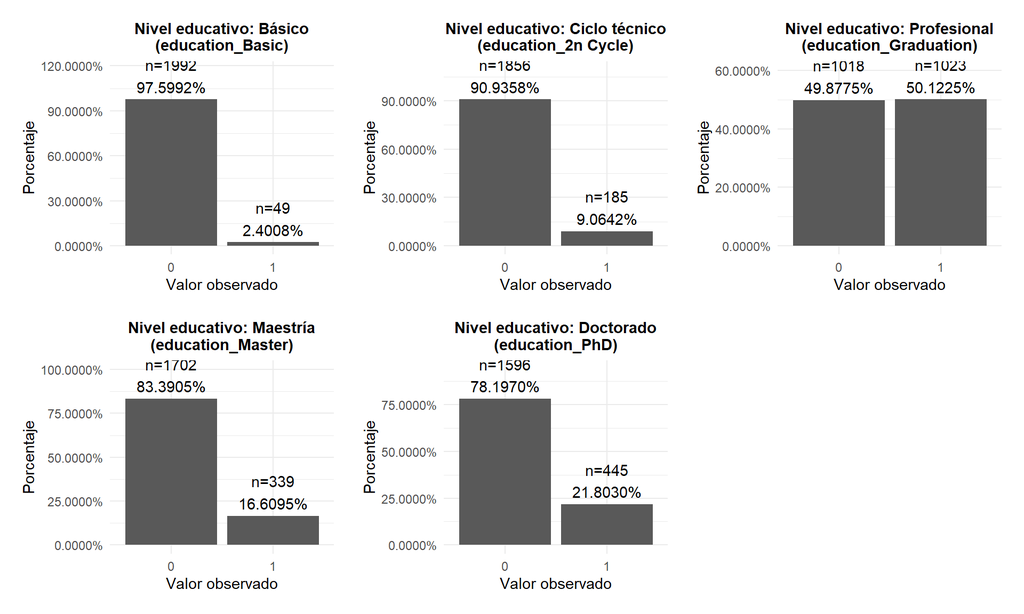

Figure 5.3: Distribución porcentual de las variables de grado de educación (One-Hot Encoding). Se incluyen valores faltantes como categoría explícita.

```r
data_temp <- datos_sin_inconsistencia_v1

vars <- c("education_Basic",
                            "education_2n Cycle",
                            "education_Graduation",
                            "education_Master",
                            "education_PhD")



plots <- lapply(vars, function(v){

  conteo <- as.data.frame(table(data_temp[[v]], useNA = "ifany"))
  colnames(conteo) <- c("valor", "n")

  conteo$pct <- conteo$n / sum(conteo$n)

  ymax <- max(conteo$pct) * 1.20

  ggplot(conteo, aes(x = factor(valor), y = pct)) +
    geom_col() +
    geom_text(aes(label = paste0("n=", n, "\n", sprintf("%.4f%%", 100*pct))),
              vjust = -0.2, size = 3.8) +
    scale_y_continuous(labels = function(x) sprintf("%.4f%%", 100*x),
                       limits = c(0, ymax)) +
    labs(
      title = stringr::str_wrap(diccionario_vars[[v]], width = 30),
      x = "Valor observado",
      y = "Porcentaje"
    ) +
    theme_minimal() +
    theme(
      plot.title = element_text(size = 11, face = "bold", hjust = 0.5),
      plot.margin = margin(10, 10, 10, 10)
    )
})

wrap_plots(plots, ncol = 3)
```

Adicionalmente se valida el grupo de variables de nivel de educación y se entienden como una variable categórica a la cual se le realizón codificación One-Hot-Encoding, por lo cual se valida inconsistencias de si algún registro no definido algún nivel de educación o si tiene más de un nivel de educación, para este grupo de registros no se encontraron inconsistencias de este tipo. El resumen de la validación está en la tabla 5.4

```r
nivel_educativo <- c("education_Basic", "education_2n Cycle",
                     "education_Graduation", "education_Master", "education_PhD")

data_temp <- datos_sin_inconsistencia_v1

suma_niveles <- rowSums(data_temp[, nivel_educativo])
n_total <- nrow(data_temp)


registros_inadecuados <- data_temp[suma_niveles != 1, ]
cantidad_inadecuados <- nrow(registros_inadecuados)
porcentaje_inadecuados <- (cantidad_inadecuados / n_total) * 100


resumen_validacion_educacion <- data.frame(
  Indicador = c(
    "Total registros analizados",
    "Registros consistentes (Suma = 1)",
    "Registros inconsistentes (Suma != 1)",
    "Porcentaje de error (%)",
    "Estado de la variable"
  ),
  Valor = c(
    n_total,
    n_total - cantidad_inadecuados,
    cantidad_inadecuados,
    round(porcentaje_inadecuados, 2),
    if(cantidad_inadecuados == 0) "impio" else "Requiere Limpieza"
  )
)


knitr::kable( resumen_estado_civil, caption = "Resumen de Validación: Nivel Educativo (One-Hot)",
             format = "html") %>%
  kable_styling(bootstrap_options = c("bordered", "striped", "hover"), full_width = F, font_size = 11)
```

| Indicador | Valor |
| --- | --- |
| Total registros analizados | 2041 |
| Registros con error (Suma != 1) | 0 |
| Porcentaje de inconsistencia (%) | 0 |
| Registros eliminados/imputados | 0 |
| Registros válidos finales | 2041 |
| Porcentaje de integridad final (%) | 100 |

#### 5.1.2.4 Otras Variables binarias

La figura 5.4 muestra la distribución de frecuencias de la variable `Response` y `Complain`, se observa que es binaria y que no tiene datos faltantes. No hay datos inconsistente. Respose será nuestro target que es la variable de aceptación de la última campaña `Response`, vemos que tiene diferente distribución que `AcceptedCmp5` por lo cual sería literal `AcceptedCmp6`.

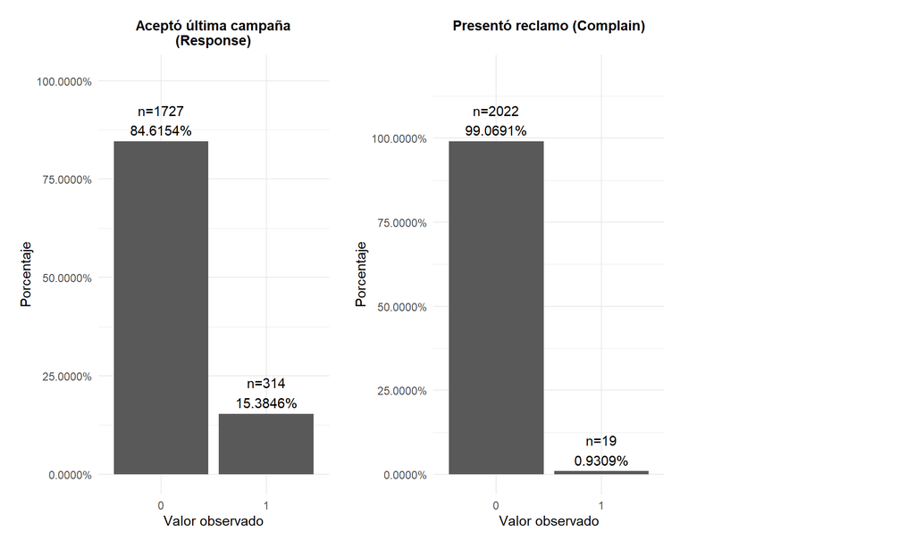

Figure 5.4: Distribución porcentual de las variables Response y Complain. Se incluyen valores faltantes como categoría explícita.

```r
data_temp <- datos_sin_inconsistencia_v1

vars <- c("Response",
 "Complain")



plots <- lapply(vars, function(v){

  conteo <- as.data.frame(table(data_temp[[v]], useNA = "ifany"))
  colnames(conteo) <- c("valor", "n")

  conteo$pct <- conteo$n / sum(conteo$n)

  ymax <- max(conteo$pct) * 1.20

  ggplot(conteo, aes(x = factor(valor), y = pct)) +
    geom_col() +
    geom_text(aes(label = paste0("n=", n, "\n", sprintf("%.4f%%", 100*pct))),
              vjust = -0.2, size = 3.8) +
    scale_y_continuous(labels = function(x) sprintf("%.4f%%", 100*x),
                       limits = c(0, ymax)) +
    labs(
      title = stringr::str_wrap(diccionario_vars[[v]], width = 30),
      x = "Valor observado",
      y = "Porcentaje"
    ) +
    theme_minimal() +
    theme(
      plot.title = element_text(size = 11, face = "bold", hjust = 0.5),
      plot.margin = margin(10, 10, 10, 10)
    )
})

wrap_plots(plots, ncol = 3)
```

#### 5.1.2.5 Variable Monetarias

La Figura 5.5 presenta el diagrama de caja de las variables monetarias, el cual permite identificar posibles valores atípicos y observar su distribución general. A partir de esta visualización, se encuentran valores extremos fuera de los límites esperados.

Este hallazgo se complementa con la Tabla 5.5, la cual resume las estadísticas descriptivas de las variables y confirma que el rango observado es coherente para el análisis.

A partir del análisis sobre estas gráficas y sus estadísticas descriptivas, se observan valores atípicos en varias variables monetarias, la mayoría de estos datos atípicos están en el grupo que no aceptó la campaña. Al revisar estos datos atípicos, exceptuando la variable `MntRegularProds`, la variable `Income` y la variable `MntWines`, los demás son valores que corresponden a montos razonables dentro del contexto y no evidencian errores como valores negativos, cifras absurdas fuera de rango, o errores de digitación. Por tanto, no se procedió a su eliminación, ya que representan variabilidad real del comportamiento de compra y su remoción podría introducir sesgo en el análisis.

Para la variable MntRegularProds se tiene un valor mínimo negativo que toca validar.La variable Income tienen 68 datos `(NA)` que requieren validación, por otro lado la variable MntWines también tiene 20 datos `(NA)`, se hará el proceso pertinente en la sección de datos faltantes.

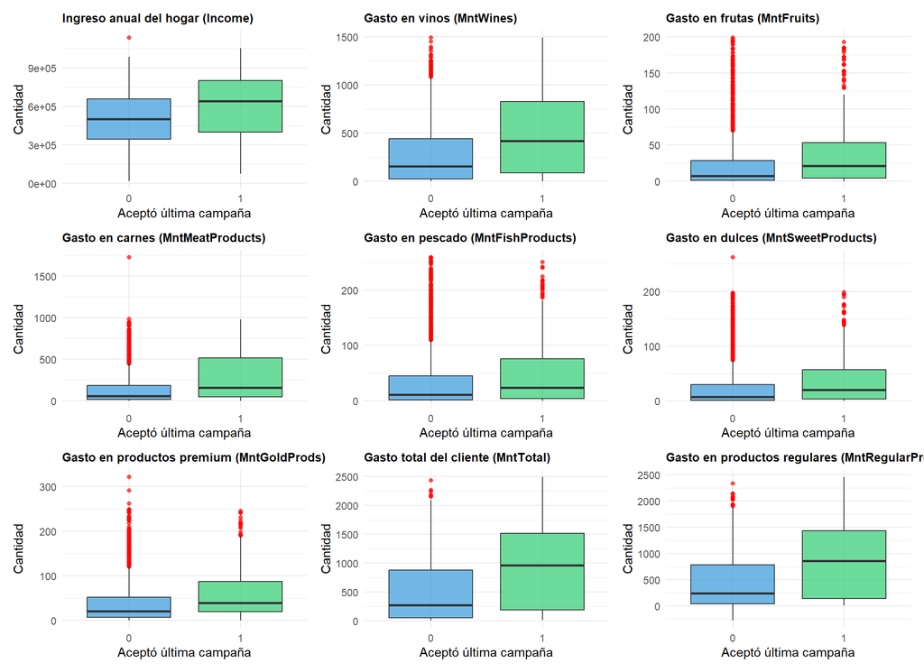

Figure 5.5: Distribución de variables monetarias según (Response, 0 = No, 1 = Sí Aceptó última campaña).

```r
data_temp <- datos_sin_inconsistencia_v1

vars_graph <- c("Income","MntWines","MntFruits","MntMeatProducts",
                "MntFishProducts","MntSweetProducts",
                "MntGoldProds","MntTotal","MntRegularProds")

plots <- lapply(vars_graph, function(v){
  ggplot(data_temp, aes(x = factor(Response), y = .data[[v]], fill = factor(Response))) +
    geom_boxplot(outlier.colour = "red", outlier.shape = 16, outlier.size = 1.5, alpha = 0.7) +
    scale_fill_manual(values = c("#3498db", "#2ecc71")) +
    labs(title = diccionario_vars[[v]],
         x = "Aceptó última campaña",
         y = "Cantidad") +
    theme_minimal() +
    theme(legend.position = "none",
          plot.title = element_text(size = 10, face = "bold"))
})

wrap_plots(plots, ncol = 3)
```

```r
data_temp <- datos_sin_inconsistencia_v1

lista_resultados <- list()
N_TOTAL <- nrow(data_temp)
vars_graph <- c("Income","MntWines","MntFruits","MntMeatProducts",
                "MntFishProducts","MntSweetProducts",
                "MntGoldProds","MntTotal","MntRegularProds")

for(v in vars_graph) {

  # División de datos por target
  g0 <- as.numeric(data_temp[[v]][which(data_temp$Response == 0)])
  g1 <- as.numeric(data_temp[[v]][which(data_temp$Response == 1)])

  procesar <- function(vec, label_cmp) {

    n_total_subgrupo <- length(vec)
    n_na <- sum(is.na(vec))
    pct_na <- (n_na / n_total_subgrupo) * 100

    vec_clean <- na.omit(vec)
    n_subdataset <- length(vec_clean)
    if(n_subdataset == 0) return(NULL)

    # --- Cálculo de Outliers (Regla 1.5 IQR) ---
    q1 <- quantile(vec_clean, 0.25)
    q3 <- quantile(vec_clean, 0.75)
    iqr_val <- q3 - q1
    lim_inf <- q1 - 1.5 * iqr_val
    lim_sup <- q3 + 1.5 * iqr_val

    # Identificar outliers
    outliers <- vec_clean[vec_clean < lim_inf | vec_clean > lim_sup]
    n_outliers <- length(outliers)

    # Porcentajes
    pct_subdataset <- (n_outliers / n_subdataset) * 100
    pct_global <- (n_outliers / N_TOTAL) * 100

    # --- Generación de estadísticos con summarytools ---
    descr(vec_clean,
          stats = c("n.valid","min","q1","med","q3","max","mean","sd","cv"),
          transpose = TRUE) %>%
      tb() %>%
      rename(Estadistico = 1) %>%
      mutate(
        Variable = v,
        Response = label_cmp,
        Outliers_N = n_outliers,
        `Pct_Outlier_Subgrupo` = pct_subdataset,
        `Pct_Outlier_Global` = pct_global,
        Datos_NA = n_na,
        Pct_Datos_NA = pct_na
      )
  }

  lista_resultados[[paste0(v, "_0")]] <- procesar(g0, 0)
  lista_resultados[[paste0(v, "_1")]] <- procesar(g1, 1)
}

# 2. Unir resultados en una sola tabla
tabla_maestra <- bind_rows(lista_resultados) %>%
  select(Variable, , everything(), -Estadistico, Outliers_N, `Pct_Outlier_Subgrupo`, `Pct_Outlier_Global`) %>%   mutate(     Variable = str_trim(as.character(Variable)),     Variable = ifelse(       Variable %in% names(diccionario_vars),       unname(diccionario_vars[Variable]),       Variable     )   )

knitr::kable(tabla_maestra,
             digits = 2,
             caption = "Análisis de Variables y Outliers (1.5*IQR) por Campaña",
             format = "html") %>%   kable_styling(bootstrap_options = c("bordered", "striped", "hover"), full_width = F, font_size = 11) %>% scroll_box(width = "700px")
```

Table 5.5: Análisis de Variables y Outliers (1.5*IQR) por Campaña

| Variable | n.valid | min | q1 | med | q3 | max | mean | sd | cv | Response | Outliers_N | Pct_Outlier_Subgrupo | Pct_Outlier_Global | Datos_NA | Pct_Datos_NA |
| --- | --- | --- | --- | --- | --- | --- | --- | --- | --- | --- | --- | --- | --- | --- | --- |
| Ingreso anual del hogar (Income) | 1668 | 17300 | 343960 | 501215.0 | 657625 | 1137340 | 501311.56 | 198803.52 | 0.40 | 0 | 1 | 0.06 | 0.05 | 59 | 3.42 |
| Ingreso anual del hogar (Income) | 305 | 75000 | 397630 | 640900.0 | 801340 | 1054710 | 601562.85 | 231628.69 | 0.39 | 1 | 0 | 0.00 | 0.00 | 9 | 2.87 |
| Gasto en vinos (MntWines) | 1715 | 0 | 22 | 155.0 | 443 | 1493 | 268.84 | 303.95 | 1.13 | 0 | 35 | 2.04 | 1.71 | 12 | 0.69 |
| Gasto en vinos (MntWines) | 306 | 1 | 88 | 418.0 | 830 | 1492 | 484.68 | 418.32 | 0.86 | 1 | 0 | 0.00 | 0.00 | 8 | 2.55 |
| Gasto en frutas (MntFruits) | 1727 | 0 | 1 | 7.0 | 29 | 199 | 24.21 | 38.16 | 1.58 | 0 | 202 | 11.70 | 9.90 | 0 | 0.00 |
| Gasto en frutas (MntFruits) | 314 | 0 | 4 | 21.0 | 53 | 193 | 38.04 | 46.17 | 1.21 | 1 | 24 | 7.64 | 1.18 | 0 | 0.00 |
| Gasto en carnes (MntMeatProducts) | 1727 | 0 | 14 | 57.0 | 188 | 1725 | 142.65 | 195.71 | 1.37 | 0 | 158 | 9.15 | 7.74 | 0 | 0.00 |
| Gasto en carnes (MntMeatProducts) | 314 | 1 | 46 | 156.5 | 514 | 981 | 294.40 | 289.85 | 0.98 | 1 | 0 | 0.00 | 0.00 | 0 | 0.00 |
| Gasto en pescado (MntFishProducts) | 1727 | 0 | 2 | 11.0 | 45 | 259 | 35.23 | 53.21 | 1.51 | 0 | 183 | 10.60 | 8.97 | 0 | 0.00 |
| Gasto en pescado (MntFishProducts) | 314 | 0 | 4 | 23.5 | 76 | 250 | 50.49 | 61.39 | 1.22 | 1 | 19 | 6.05 | 0.93 | 0 | 0.00 |
| Gasto en dulces (MntSweetProducts) | 1727 | 0 | 1 | 7.0 | 30 | 262 | 25.30 | 40.38 | 1.60 | 0 | 201 | 11.64 | 9.85 | 0 | 0.00 |
| Gasto en dulces (MntSweetProducts) | 314 | 0 | 3 | 20.0 | 57 | 198 | 38.57 | 46.45 | 1.20 | 1 | 19 | 6.05 | 0.93 | 0 | 0.00 |
| Gasto en productos premium (MntGoldProds) | 1727 | 0 | 7 | 21.0 | 53 | 321 | 40.53 | 49.76 | 1.23 | 0 | 150 | 8.69 | 7.35 | 0 | 0.00 |
| Gasto en productos premium (MntGoldProds) | 314 | 0 | 20 | 40.0 | 88 | 245 | 62.31 | 58.25 | 0.93 | 1 | 16 | 5.10 | 0.78 | 0 | 0.00 |
| Gasto total del cliente (MntTotal) | 1727 | 4 | 49 | 276.0 | 883 | 2429 | 499.86 | 528.42 | 1.06 | 0 | 6 | 0.35 | 0.29 | 0 | 0.00 |
| Gasto total del cliente (MntTotal) | 314 | 14 | 184 | 965.5 | 1517 | 2491 | 919.87 | 697.62 | 0.76 | 1 | 0 | 0.00 | 0.00 | 0 | 0.00 |
| Gasto en productos regulares (MntRegularProds) | 1727 | -283 | 38 | 242.0 | 785 | 2333 | 459.33 | 506.53 | 1.10 | 0 | 16 | 0.93 | 0.78 | 0 | 0.00 |
| Gasto en productos regulares (MntRegularProds) | 314 | 3 | 135 | 858.5 | 1430 | 2458 | 857.56 | 681.54 | 0.79 | 1 | 0 | 0.00 | 0.00 | 0 | 0.00 |

```r
data_temp = datos_sin_inconsistencia_v1
categorias_v1 <- c("MntWines", "MntFruits", "MntMeatProducts", "MntFishProducts", "MntSweetProducts")
categorias_v2 <- c("MntGoldProds", "MntRegularProds")


n_total <- nrow(data_temp)


suma_v1 <- rowSums(data_temp[, categorias_v1], na.rm = TRUE)
inconsistentes_v1 <- sum(data_temp$MntTotal != suma_v1)
pct_v1 <- (inconsistentes_v1 / n_total) * 100


suma_v2 <- rowSums(data_temp[, categorias_v2], na.rm = TRUE)
inconsistentes_v2 <- sum(data_temp$MntTotal != suma_v2)
pct_v2 <- (inconsistentes_v2 / n_total) * 100


resumen_monetario <- data.frame(
  Validacion_Estructural = c(
    "MntTotal = Suma Categorías (Wines, Fruits, Meat, Fish y Sweet)",
    "MntTotal = MntGoldProds + MntRegularProds"
  ),
  Registros_Inconsistentes = c(inconsistentes_v1, inconsistentes_v2),
  Porcentaje_Error = c(
    paste0(round(pct_v1, 2), "%"),
    paste0(round(pct_v2, 2), "%")
  ),
  Estado = c(
    if(inconsistentes_v1 == 0) "Correcto" else "Inconsistente",
    if(inconsistentes_v2 == 0) "Correcto" else "Inconsistente"
  )
)

knitr::kable(resumen_monetario,
             digits = 2,
             caption = "Resumen inconsistencias en variables monetarias",
             format = "html") %>%   kable_styling(bootstrap_options = c("bordered", "striped", "hover"), full_width = F, font_size = 11)
```

Table 5.6: Resumen inconsistencias en variables monetarias

| Validacion_Estructural | Registros_Inconsistentes | Porcentaje_Error | Estado |
| --- | --- | --- | --- |
| MntTotal = Suma Categorías (Wines, Fruits, Meat, Fish y Sweet) | 20 | 0.98% | Inconsistente |
| MntTotal = MntGoldProds + MntRegularProds | 0 | 0% | Correcto |

```r
data_temp <- datos_sin_inconsistencia_v1

categorias_productos <- c("MntWines","MntFruits","MntMeatProducts",
                     "MntFishProducts","MntSweetProducts")


data_temp$suma_calculada_productos <- rowSums(data_temp[, categorias_productos], na.rm = TRUE) # na.rm = TRUE trata nan como 0


registros_inconsistentes_mnt <- data_temp[data_temp$MntTotal != data_temp$suma_calculada_productos, ]


registros_inconsistentes_negativos =  data_temp %>%
  select(all_of(vars_graph)) %>%
  filter(MntRegularProds < 0)

columnas_muestra =  c("MntTotal", "MntWines","MntFruits","MntMeatProducts",
                     "MntFishProducts","MntSweetProducts", "MntGoldProds","MntRegularProds")

tabla_inconsistencia_montos = rbind(head(registros_inconsistentes_mnt[, c(columnas_muestra)]),
                                    head(registros_inconsistentes_negativos[, c(columnas_muestra)]))

knitr::kable(tabla_inconsistencia_montos,
             caption = "Datos inconsistentes en Mnt hallazgos de (NA) y de datos negativos",
             format = "html") %>%   kable_styling(bootstrap_options = c("bordered", "striped", "hover"), full_width = F, font_size = 11)
```

Table 5.7: Datos inconsistentes en Mnt hallazgos de (NA) y de datos negativos

| MntTotal | MntWines | MntFruits | MntMeatProducts | MntFishProducts | MntSweetProducts | MntGoldProds | MntRegularProds |
| --- | --- | --- | --- | --- | --- | --- | --- |
| 702 | NA | 42 | 98 | 0 | 42 | 14 | 688 |
| 1270 | NA | 22 | 115 | 59 | 68 | 45 | 1225 |
| 1809 | NA | 71 | 449 | 69 | 71 | 26 | 1783 |
| 1599 | NA | 16 | 417 | 42 | 48 | 16 | 1583 |
| 1367 | NA | 68 | 103 | 29 | 91 | 68 | 1299 |
| 1775 | NA | 155 | 379 | 224 | 17 | 120 | 1655 |
| 111 | 67 | 11 | 26 | 4 | 3 | 262 | -151 |
| 125 | 81 | 4 | 33 | 5 | 2 | 291 | -166 |
| 38 | 16 | 4 | 12 | 2 | 4 | 321 | -283 |

Se valida en la Tabla 5.6 y en la Tabla 5.7 y se evidencia que la variable `MntTotal` es una variable derivada: `MntTotal` = `MntWines` + `MntFruits` + `MntMeatProducts` + `MntFishProducts` + `MntSweetProducts` donde solo hay 0.98% de inconsistencia en la suma debido a valores `(NA)`, tambien se valida que `MntTotal` = `MntGoldProds` + `MntRegularProds` en el 100% de los casos, pero tenemos `MntRegularProds` 3 datos negativos, esto quiere decir que `MntRegularProds` se calculó con `MntTotal` - `MntGoldProds`, al tener esta inconsistencia se ve que hay unas operaciones no adecuadas para generar tanto `MntTotal` como `MntRegularProds`.

Para corregir esto se debe hacer las imputaciones de datos `(NA)` en la variable `MntWines` y se debe recalcular `MntTotal` = `MntWines` + `MntFruits` + `MntMeatProducts` + `MntFishProducts` + `MntSweetProducts` +`MntGoldProds` y también recalcular `MntRegularProds` = `MntTotal` - `MntGoldProds`, teniendo como valores de verdad las columnas principles de montos en productos y entendiendo que `MntGoldProds` hace parte del `MntTotal`, así podermos realizar los calculos adecuados de las variables derivadas.

#### 5.1.2.6 Variable Cuantitativas discretas

La Figura 5.6 presenta el diagrama de caja de las variables cuantitativas discretas, el cual permite identificar posibles valores atípicos y observar su distribución general. A partir de esta visualización, se encuentran valores extremos fuera de los límites esperados.

Este hallazgo se complementa con la Tabla 5.8, la cual resume las estadísticas descriptivas de las variables y confirma que el rango observado es coherente para el análisis.

A partir del análisis sobre estas gráficas y sus estadísticas descriptivas, se observan valores atípicos en varias variables cuantitativas discretas, la mayoría de estos datos atípicos están en el grupo que no aceptó la campaña. Al revisar estos datos atípicos, exceptuando la variable `Age`, los demás son valores que corresponden a rangos razonables dentro del contexto y no evidencian errores como valores negativos, cifras absurdas fuera de rango, o errores de digitación. Por tanto, no se procedió a su eliminación, ya que representan variabilidad real del comportamientos y caracteristicas del usuario y su remoción podría introducir sesgo en el análisis. Para la variable `Age` se tiene valores de 240 como máximo y se deben validar.

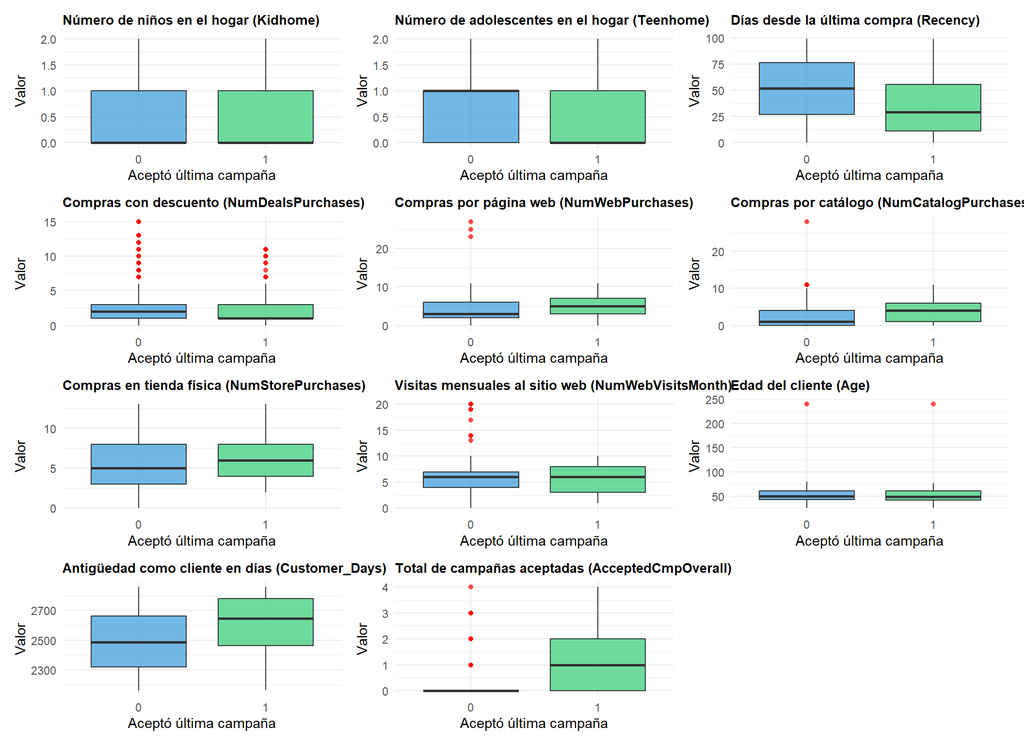

Figure 5.6: Distribución de variablescuantitativas discretas según (0 = No, 1 = Sí Aceptó última campaña).

```r
data_temp <- datos_sin_inconsistencia_v1

vars_graph <- c(
  "Kidhome",
  "Teenhome",
  "Recency",
  "NumDealsPurchases",
  "NumWebPurchases",
  "NumCatalogPurchases",
  "NumStorePurchases",
  "NumWebVisitsMonth",
  "Age",
  "Customer_Days",
  "AcceptedCmpOverall"
)

plots <- lapply(vars_graph, function(v){
  ggplot(data_temp, aes(x = factor(Response), y = .data[[v]], fill = factor(Response))) +
    geom_boxplot(outlier.colour = "red", outlier.shape = 16, outlier.size = 1.5, alpha = 0.7) +
    scale_fill_manual(values = c("#3498db", "#2ecc71")) +
    labs(title = diccionario_vars[[v]],
         x = "Aceptó última campaña",
         y = "Valor") +
    theme_minimal() +
    theme(legend.position = "none",
          plot.title = element_text(size = 10, face = "bold"))
})

wrap_plots(plots, ncol = 3)
```

```r
data_temp <- datos_sin_inconsistencia_v1

lista_resultados <- list()
N_TOTAL <- nrow(data_temp)

vars_graph <- c(
  "Kidhome",
  "Teenhome",
  "Recency",
  "NumDealsPurchases",
  "NumWebPurchases",
  "NumCatalogPurchases",
  "NumStorePurchases",
  "NumWebVisitsMonth",
  "Age",
  "Customer_Days",
  "AcceptedCmpOverall"
)

for(v in vars_graph) {

  # División de datos por target
  g0 <- as.numeric(data_temp[[v]][which(data_temp$Response == 0)])
  g1 <- as.numeric(data_temp[[v]][which(data_temp$Response == 1)])

  procesar <- function(vec, label_cmp) {

    n_total_subgrupo <- length(vec)
    n_na <- sum(is.na(vec))
    pct_na <- (n_na / n_total_subgrupo) * 100

    vec_clean <- na.omit(vec)
    n_subdataset <- length(vec_clean)
    if(n_subdataset == 0) return(NULL)

    # --- Cálculo de Outliers (Regla 1.5 IQR) ---
    q1 <- quantile(vec_clean, 0.25)
    q3 <- quantile(vec_clean, 0.75)
    iqr_val <- q3 - q1
    lim_inf <- q1 - 1.5 * iqr_val
    lim_sup <- q3 + 1.5 * iqr_val

    # Identificar outliers
    outliers <- vec_clean[vec_clean < lim_inf | vec_clean > lim_sup]
    n_outliers <- length(outliers)

    # Porcentajes
    pct_subdataset <- (n_outliers / n_subdataset) * 100
    pct_global <- (n_outliers / N_TOTAL) * 100

    # --- Generación de estadísticos con summarytools ---
    descr(vec_clean,
          stats = c("n.valid","min","q1","med","q3","max","mean","sd","cv"),
          transpose = TRUE) %>%
      tb() %>%
      rename(Estadistico = 1) %>%
      mutate(
        Variable = v,
        Response = label_cmp,
        Outliers_N = n_outliers,
        `Pct_Outlier_Subgrupo` = pct_subdataset,
        `Pct_Outlier_Global` = pct_global,
        Datos_NA = n_na,
        Pct_Datos_NA = pct_na
      )
  }

  lista_resultados[[paste0(v, "_0")]] <- procesar(g0, 0)
  lista_resultados[[paste0(v, "_1")]] <- procesar(g1, 1)
}

# 2. Unir resultados en una sola tabla
tabla_maestra <- bind_rows(lista_resultados) %>%
  select(Variable, Response, everything(), -Estadistico, Outliers_N, `Pct_Outlier_Subgrupo`, `Pct_Outlier_Global`) %>%   mutate(     Variable = str_trim(as.character(Variable)),     Variable = ifelse(       Variable %in% names(diccionario_vars),       unname(diccionario_vars[Variable]),       Variable     )   )

knitr::kable(tabla_maestra,
             digits = 2,
             caption = "Análisis de Variables y Outliers (1.5*IQR) por Campaña",
             format = "html") %>%   kable_styling(bootstrap_options = c("bordered", "striped", "hover"), full_width = F, font_size = 11) %>% scroll_box(width = "700px")
```

Table 5.8: Análisis de Variables y Outliers (1.5*IQR) por Campaña

| Variable | Response | n.valid | min | q1 | med | q3 | max | mean | sd | cv | Outliers_N | Pct_Outlier_Subgrupo | Pct_Outlier_Global | Datos_NA | Pct_Datos_NA |
| --- | --- | --- | --- | --- | --- | --- | --- | --- | --- | --- | --- | --- | --- | --- | --- |
| Número de niños en el hogar (Kidhome) | 0 | 1727 | 0 | 0 | 0.0 | 1 | 2 | 0.46 | 0.54 | 1.18 | 0 | 0.00 | 0.00 | 0 | 0 |
| Número de niños en el hogar (Kidhome) | 1 | 314 | 0 | 0 | 0.0 | 1 | 2 | 0.34 | 0.49 | 1.44 | 0 | 0.00 | 0.00 | 0 | 0 |
| Número de adolescentes en el hogar (Teenhome) | 0 | 1727 | 0 | 0 | 1.0 | 1 | 2 | 0.54 | 0.55 | 1.01 | 0 | 0.00 | 0.00 | 0 | 0 |
| Número de adolescentes en el hogar (Teenhome) | 1 | 314 | 0 | 0 | 0.0 | 1 | 2 | 0.31 | 0.49 | 1.62 | 0 | 0.00 | 0.00 | 0 | 0 |
| Días desde la última compra (Recency) | 0 | 1727 | 0 | 27 | 52.0 | 77 | 99 | 51.47 | 28.50 | 0.55 | 0 | 0.00 | 0.00 | 0 | 0 |
| Días desde la última compra (Recency) | 1 | 314 | 0 | 11 | 29.0 | 56 | 99 | 34.82 | 27.31 | 0.78 | 0 | 0.00 | 0.00 | 0 | 0 |
| Compras con descuento (NumDealsPurchases) | 0 | 1727 | 0 | 1 | 2.0 | 3 | 15 | 2.32 | 1.85 | 0.80 | 57 | 3.30 | 2.79 | 0 | 0 |
| Compras con descuento (NumDealsPurchases) | 1 | 314 | 0 | 1 | 1.0 | 3 | 11 | 2.33 | 2.10 | 0.90 | 17 | 5.41 | 0.83 | 0 | 0 |
| Compras por página web (NumWebPurchases) | 0 | 1727 | 0 | 2 | 3.0 | 6 | 27 | 3.94 | 2.75 | 0.70 | 3 | 0.17 | 0.15 | 0 | 0 |
| Compras por página web (NumWebPurchases) | 1 | 314 | 0 | 3 | 5.0 | 7 | 11 | 5.07 | 2.57 | 0.51 | 0 | 0.00 | 0.00 | 0 | 0 |
| Compras por catálogo (NumCatalogPurchases) | 0 | 1727 | 0 | 0 | 1.0 | 4 | 28 | 2.37 | 2.64 | 1.12 | 10 | 0.58 | 0.49 | 0 | 0 |
| Compras por catálogo (NumCatalogPurchases) | 1 | 314 | 0 | 1 | 4.0 | 6 | 11 | 4.18 | 3.12 | 0.75 | 0 | 0.00 | 0.00 | 0 | 0 |
| Compras en tienda física (NumStorePurchases) | 0 | 1727 | 0 | 3 | 5.0 | 8 | 13 | 5.76 | 3.26 | 0.57 | 0 | 0.00 | 0.00 | 0 | 0 |
| Compras en tienda física (NumStorePurchases) | 1 | 314 | 2 | 4 | 6.0 | 8 | 13 | 6.05 | 3.09 | 0.51 | 0 | 0.00 | 0.00 | 0 | 0 |
| Visitas mensuales al sitio web (NumWebVisitsMonth) | 0 | 1727 | 0 | 4 | 6.0 | 7 | 20 | 5.35 | 2.40 | 0.45 | 9 | 0.52 | 0.44 | 0 | 0 |
| Visitas mensuales al sitio web (NumWebVisitsMonth) | 1 | 314 | 1 | 3 | 6.0 | 8 | 10 | 5.30 | 2.56 | 0.48 | 0 | 0.00 | 0.00 | 0 | 0 |
| Edad del cliente (Age) | 0 | 1727 | 25 | 43 | 50.0 | 61 | 240 | 51.40 | 12.37 | 0.24 | 1 | 0.06 | 0.05 | 0 | 0 |
| Edad del cliente (Age) | 1 | 314 | 25 | 41 | 49.0 | 61 | 240 | 51.11 | 16.28 | 0.32 | 1 | 0.32 | 0.05 | 0 | 0 |
| Antigüedad como cliente en días (Customer_Days) | 0 | 1727 | 2159 | 2320 | 2486.0 | 2661 | 2857 | 2494.75 | 198.74 | 0.08 | 0 | 0.00 | 0.00 | 0 | 0 |
| Antigüedad como cliente en días (Customer_Days) | 1 | 314 | 2165 | 2461 | 2645.5 | 2780 | 2858 | 2602.67 | 199.59 | 0.08 | 0 | 0.00 | 0.00 | 0 | 0 |
| Total de campañas aceptadas (AcceptedCmpOverall) | 0 | 1727 | 0 | 0 | 0.0 | 0 | 4 | 0.18 | 0.48 | 2.64 | 255 | 14.77 | 12.49 | 0 | 0 |
| Total de campañas aceptadas (AcceptedCmpOverall) | 1 | 314 | 0 | 0 | 1.0 | 2 | 4 | 0.98 | 1.11 | 1.13 | 0 | 0.00 | 0.00 | 0 | 0 |

```r
data_temp <- datos_sin_inconsistencia_v1
n_inicial <- nrow(data_temp)

datos_sin_inconsistencia_v2 <- data_temp %>%
  filter(Age <= 100 | is.na(Age))

n_final <- nrow(datos_sin_inconsistencia_v2)
eliminados <- n_inicial - n_final
porcentaje_eliminado <- (eliminados / n_inicial) * 100
porcentaje_restante <- (n_final / n_inicial) * 100

resumen_limpieza_edad <- data.frame(
  Indicador = c(
    "Registros iniciales",
    "Registros eliminados (Age > 100)",
    "Registros finales válidos",
    "Porcentaje de registros eliminados",
    "Porcentaje de registros conservados"
  ),
  Valor_Neto = c(
    n_inicial,
    eliminados,
    n_final,
    round(porcentaje_eliminado, 4),
    round(porcentaje_restante, 4)
  ),
  Unidad = c("Filas", "Filas", "Filas", "%", "%")
)

knitr::kable(resumen_limpieza_edad,
             digits = 2,
             caption = "Resumen de Limpieza: Datos de Edad con valores atípicos no posibles en la realidad.",
             format = "html") %>%   kable_styling(bootstrap_options = c("bordered", "striped", "hover"), full_width = F, font_size = 11)
```

Table 5.9: Resumen de Limpieza: Datos de Edad con valores atípicos no posibles en la realidad.

| Indicador | Valor_Neto | Unidad |
| --- | --- | --- |
| Registros iniciales | 2041.0 | Filas |
| Registros eliminados (Age > 100) | 2.0 | Filas |
| Registros finales válidos | 2039.0 | Filas |
| Porcentaje de registros eliminados | 0.1 | % |
| Porcentaje de registros conservados | 99.9 | % |

Se hace la verificación que se observa en la Tabla 5.9 que la variable `Age` tenía 2 edades que mostraban inconsistencias, en la Tabla 5.8 se ve que tienen un valor máximo de 240 años, de por si representa un 0.098% de los datos, se procede a eliminar los valores. La eliminación se justifica debido a que es un error estructural de los datos, no un outlier ya que no tiene sentido un humano con esa edad, tratar de imputarlo podría ser un error y generar afectaciones a los datos. La decisión no afectan representatividad, no alteran distribución, no sesgan muestra, realmente no generan pérdida significativa de información.

Se realiza también la validación de que `AcceptedCmpOverall` = `AcceptedCmp1` + `AcceptedCmp2` + `AcceptedCmp3` + `AcceptedCmp4` + `AcceptedCmp5` donde no se encuentran inconsistencias, y se verifica que la columna derivada es correcta. El resumen de imputaicón se puede ve en la Tabla 5.10.

```r
data_temp <- datos_sin_inconsistencia_v2

validacion_cmp <- data_temp %>%
  mutate(
    suma_cmp = AcceptedCmp1 + AcceptedCmp2 + AcceptedCmp3 +
               AcceptedCmp4 + AcceptedCmp5,

    inconsistencia = AcceptedCmpOverall != suma_cmp
  )

n_inconsistencias <- sum(validacion_cmp$inconsistencia, na.rm = TRUE)

# Resumen estadístico
resumen_cmp <- validacion_cmp %>%
  summarise(
    "total registros" = n(),
    "inconsistencias" = sum(inconsistencia, na.rm = TRUE),
    "porcentaje inconsistencia" = round(mean(inconsistencia, na.rm = TRUE) * 100, 4),
    "Estado de integridad" = if(n_inconsistencias == 0) "Todo coincide" else "Revisar sumatorias"
  )

knitr::kable(resumen_cmp,
             digits = 2,
             caption = "Resumen de Validación: AcceptedCmpOverall vs. Suma de Campañas",
             format = "html") %>%   kable_styling(bootstrap_options = c("bordered", "striped", "hover"), full_width = F, font_size = 11)
```

Table 5.10: Resumen de Validación: AcceptedCmpOverall vs. Suma de Campañas

| total registros | inconsistencias | porcentaje inconsistencia | Estado de integridad |
| --- | --- | --- | --- |
| 2039 | 0 | 0 | Todo coincide |

### 5.1.3 Análisis de datos atípicos

Según los hallazgos, los valores atípicos detectados en la variables corresponden a inconsistencias que se han recodificado como valores faltantes `(NA)` para `Income` y `MntWines`, los que posteriormente serán imputados. Por su parte, la variables `Age` requirió un tratamiento de eliminación debido a unos datos inconsistentes. La variable `MntRegularProds` tenia valores negativos y la variable `MntTotal` no ha sido bien calculada, estas dos variables deben ser reconstruidas después del proceso de imputación de datos faltantes. Por último, la variable `marital_Divorced` tenia unos datos en `100` que se imputaron en `1` con el supuesto de un error de digitación.

### 5.1.4 Identificación de datos faltantes

La Figura 5.7 muestra que las variables `Income` y `MntWines` en las cuales se concentran el porcentaje de datos faltantes, Asimismo, evidencia que el porcentaje más alto de datos faltantes no supera el 3.3%.

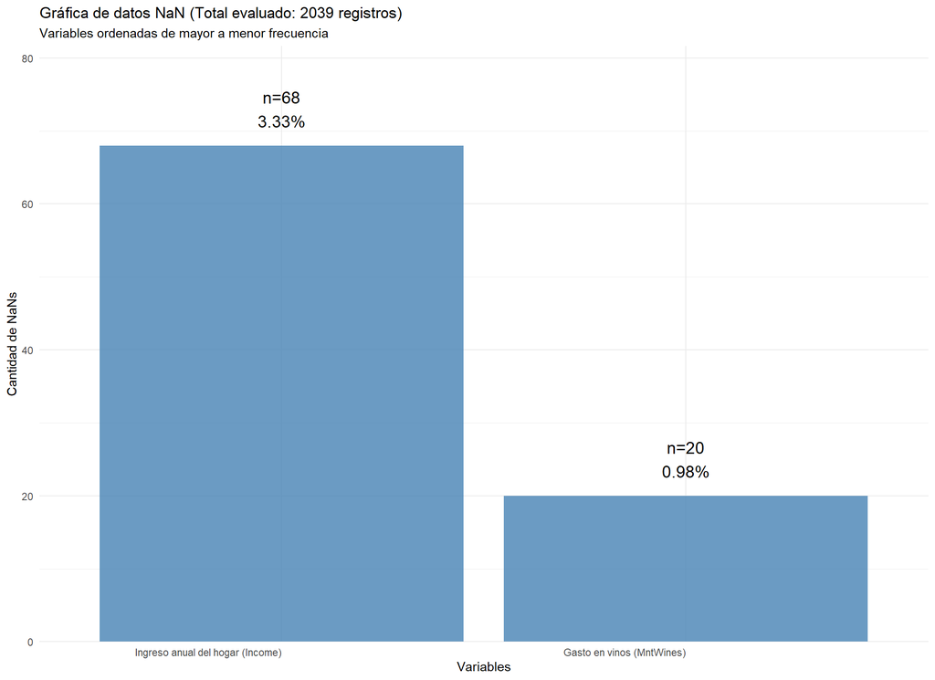

Figure 5.7: Distribución de datos faltantes en las variables.

```r
data_temp <- datos_sin_inconsistencia_v2
graficar_nans <- function(data_temp, temp_columns, diccionario_vars) {

  total_datos <- nrow(data_temp)

  resumen_nan <- data_temp %>%
    select(all_of(temp_columns)) %>%
    summarise(across(everything(), ~ sum(is.na(.)))) %>%
    pivot_longer(everything(), names_to = "Variable", values_to = "Cantidad") %>%
    mutate(Porcentaje = round((Cantidad / total_datos) * 100, 2)) %>%
    filter(Cantidad > 0) %>%
    arrange(desc(Cantidad))  %>%   mutate(     Variable = str_trim(as.character(Variable)),     Variable = ifelse(       Variable %in% names(diccionario_vars),       unname(diccionario_vars[Variable]),       Variable     )   )

  if(nrow(resumen_nan) == 0) {
    message("No se encontraron valores NaN en las columnas seleccionadas.")
    return(invisible(NULL))
  }

  ggplot(resumen_nan, aes(x = reorder(Variable, -Cantidad), y = Cantidad)) +
    geom_bar(stat = "identity", fill = "steelblue", alpha = 0.8) +
    geom_text(aes(label = paste0("n=", Cantidad, "\n", Porcentaje, "%")),
              vjust = -0.5, size = 5) +
    labs(
      title = paste("Gráfica de datos NaN (Total evaluado:", total_datos, "registros)"),
      x = "Variables",
      y = "Cantidad de NaNs",
      subtitle = "Variables ordenadas de mayor a menor frecuencia"
    ) +
    theme_minimal() +
    theme(axis.text.x = element_text(angle = 0, hjust = 1)) +
    scale_y_continuous(expand = expansion(mult = c(0, 0.2)))
}


data_temp = datos_sin_inconsistencia_v2
temp_columns <- c( "Income","Kidhome","Teenhome","Recency","MntWines","MntFruits", "MntMeatProducts","MntFishProducts","MntSweetProducts","MntGoldProds", "NumDealsPurchases","NumWebPurchases","NumCatalogPurchases","NumStorePurchases", "NumWebVisitsMonth","AcceptedCmp3","AcceptedCmp4","AcceptedCmp5", "AcceptedCmp1","AcceptedCmp2","Complain","Response","Age", "Customer_Days","marital_Divorced","marital_Married","marital_Single", "marital_Together","marital_Widow","education_2n Cycle","education_Basic", "education_Graduation","education_Master","education_PhD","MntTotal", "MntRegularProds","AcceptedCmpOverall" )

graficar_nans(data_temp, temp_columns, diccionario_vars)
```

Para evaluar formalmente si los datos faltantes se distribuyen de manera completamente aleatoria (MCAR), se aplica la prueba de Little que se implementada en la libreria `naniar::mcar_test()` a los datos, esta prueba cuya hipótesis nula establece que los datos faltantes se distribuyen de forma aleatoria. Dado el gran tamaño de la base de datos (2039 registros), se estableció un nivel de significancia de 0.001. Para poder realizar el proceso debemos quitar del análisis las Variables derivadas,Variables casi constantes y Variables perfectamente correlacionadas. Por lo cual se retiran del análisis las variables: `"MntTotal"`, `"MntRegularProds"` y `"AcceptedCmpOverall"` por ser derivadas, y las variables `"marital_Widow"` y`"education_PhD"` por multicolinealidad (propia de one-hot-econding). Esto no quiere decir que se eliminen del dataset, debido a que es un modelo de clasificación de si acepta o no la campaña, y en estos modelos la multicolinealidad no afecta como en los de regresión, tampoco las variables derivadas, antes pueden ayudar a impulsar un mejor ajuste en el modelo.

```r
data_temp <- datos_sin_inconsistencia_v2
temp_columns <- c( "Income","Kidhome","Teenhome","Recency","MntWines","MntFruits", "MntMeatProducts","MntFishProducts","MntSweetProducts","MntGoldProds", "NumDealsPurchases","NumWebPurchases","NumCatalogPurchases","NumStorePurchases", "NumWebVisitsMonth","AcceptedCmp3","AcceptedCmp4","AcceptedCmp5", "AcceptedCmp1","AcceptedCmp2","Complain","Response","Age", "Customer_Days","marital_Divorced","marital_Married","marital_Single", "marital_Together","education_2n Cycle","education_Basic", "education_Graduation","education_Master")
sub_mcar <- data_temp[, temp_columns] %>% dplyr::mutate(dplyr::across(everything(), as.numeric))

resultado_mcar <- naniar::mcar_test(sub_mcar)


knitr::kable(resultado_mcar,
             caption = "Resultados de aplicación de prueba mcar a datos",
             format = "html") %>%
  kable_styling(bootstrap_options = c("bordered", "striped", "hover"), full_width = F, font_size = 11)
```

Table 5.11: Resultados de aplicación de prueba mcar a datos

| statistic | df | p.value | missing.patterns |
| --- | --- | --- | --- |
| 131.5536 | 62 | 6e-07 | 3 |

En la Tabla 5.11 El valor p obtenido fue igual a 6.416355e-07, lo que lleva a rechazar la hipótesis nula con una significancia del 1%. Esto indica que existe evidencia suficiente para decir que los datos faltantes no son completamente aleatorios, tienen sesgo.

Dado esto no se puede hacer imputaciones como la media y la mediana. Por lo cual debemos requerir otros procesos, en cuanto a `"MntWines"` tenemos que `MntTotal` = `MntWines` + `MntFruits` + `MntMeatProducts` + `MntFishProducts` + `MntSweetProducts` +`MntGoldProds` y como solo el dato de `MntTotal` es inconsistente cuando `MntWines` es `(NA)` procederemos a recuperar el dato de `MntWines` = `MntTotal` - `MntFruits` - `MntMeatProducts` - `MntFishProducts` - `MntSweetProducts` -`MntGoldProds. El resumen de imputaicón se puede ve en la Tabla 5.12.

```r
data_temp <- datos_sin_inconsistencia_v2
datos_sin_inconsistencia_v3 <- data_temp %>%
  mutate(MntWines = ifelse(is.na(MntWines),
                           MntTotal - (MntFruits + MntMeatProducts + MntFishProducts + MntSweetProducts + MntGoldProds),
                           MntWines))

n_total <- nrow(datos_sin_inconsistencia_v2)
nas_antes <- sum(is.na(datos_sin_inconsistencia_v2$MntWines))
nas_despues <- sum(is.na(datos_sin_inconsistencia_v3$MntWines))
datos_imputados <- nas_antes - nas_despues
pct_imputados <- (datos_imputados / n_total) * 100

resumen_mntwines <- data.frame(
  Concepto = c(
    "NAs originales en MntWines",
    "Cantidad de registros imputados",
    "Porcentaje de datos imputados (%)",
    "NAs después de imputación (Validación)"
  ),
  Valor = c(
    nas_antes,
    datos_imputados,
    round(pct_imputados, 2),
    nas_despues
  )
)

knitr::kable(resumen_mntwines,
             caption = "Resultados de aplicación de imputación de datos de variable MntWines con recuperación del dato",
             format = "html") %>%
  kable_styling(bootstrap_options = c("bordered", "striped", "hover"), full_width = F, font_size = 11)
```

Table 5.12: Resultados de aplicación de imputación de datos de variable MntWines con recuperación del dato

| Concepto | Valor |
| --- | --- |
| NAs originales en MntWines | 20.00 |
| Cantidad de registros imputados | 20.00 |
| Porcentaje de datos imputados (%) | 0.98 |
| NAs después de imputación (Validación) | 0.00 |

Después de esta imputación de datos `(NA)`evaluamos de nuevo si los datos faltantes se distribuyen de manera completamente aleatoria (MCAR), de acá encontramos en la Tabla 5.13 que con un El valor p obtenido fue igual a 0.3058334, podemos aceptar la hipótesis nula con una significancia del 1%. Esto indica que existe evidencia suficiente para decir que los datos faltantes son completamente aleatorios y podemos imputar la variable Income con la media o la mediana.

```r
data_temp <- datos_sin_inconsistencia_v3
temp_columns <- c( "Income","Kidhome","Teenhome","Recency","MntWines","MntFruits", "MntMeatProducts","MntFishProducts","MntSweetProducts","MntGoldProds", "NumDealsPurchases","NumWebPurchases","NumCatalogPurchases","NumStorePurchases", "NumWebVisitsMonth","AcceptedCmp3","AcceptedCmp4","AcceptedCmp5", "AcceptedCmp1","AcceptedCmp2","Complain","Response","Age", "Customer_Days","marital_Divorced","marital_Married","marital_Single", "marital_Together","education_2n Cycle","education_Basic", "education_Graduation","education_Master")
sub_mcar <- data_temp[, temp_columns] %>% dplyr::mutate(dplyr::across(everything(), as.numeric))

resultado_mcar <- naniar::mcar_test(sub_mcar)

knitr::kable(resultado_mcar,
             caption = "Resultados de aplicación de prueba mcar a datos",
             format = "html") %>%
  kable_styling(bootstrap_options = c("bordered", "striped", "hover"), full_width = F, font_size = 11)
```

Table 5.13: Resultados de aplicación de prueba mcar a datos

| statistic | df | p.value | missing.patterns |
| --- | --- | --- | --- |
| 34.45659 | 31 | 0.3058334 | 2 |

### 5.1.5 Imputación de datos faltantes e inconsistentes

#### 5.1.5.1 Imputación de Monto de gasto en vinos (MntWines)

Se mostró anteriormente que se debio imputar este dato usando el calculo registrado ya en los datos. Teniendo en cuenta que `"MntWines"` se usa en la ecuación `MntTotal` = `MntWines` + `MntFruits` + `MntMeatProducts` + `MntFishProducts` + `MntSweetProducts` +`MntGoldProds` y como solo el dato de `MntTotal` es inconsistente cuando `MntWines` es `(NA)` se procedió a recuperar el dato de `MntWines` = `MntTotal` - `MntFruits` - `MntMeatProducts` - `MntFishProducts` - `MntSweetProducts` -`MntGoldProds`. Esto nos permitió saber que la variable Income que tambien tiene datos faltantes es producto del azar mediante la prueba mcar. El resumen de imputaicón se puede ve en la Tabla 5.12.

#### 5.1.5.2 Imputación de Ingresos (Income)

En la figura 5.8 podemos ver que puede haber una tendencia a normalidad.

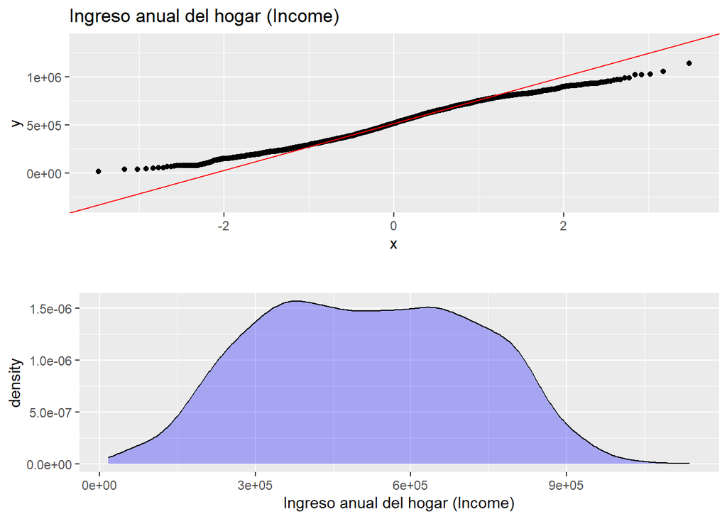

Figure 5.8: Q-Q de Income. Además, densidad de Income

Se calculo medidas de tendencia central y en la Tabla 5.14 se puede observar la imputación del dato en base a la media al no tener mucha diferencia con la mediana.

```r
 # --- Evaluar cercanía media vs mediana e imputar Income ---
data_temp <- datos_sin_inconsistencia_v3

x <- data_temp$Income
n_total <- length(x)
n_nas_inicial <- sum(is.na(x))

media <- mean(x, na.rm = TRUE)
mediana <- median(x, na.rm = TRUE)

diff_rel_pct <- abs(media - mediana) / abs(mediana) * 100

umbral_pct <- 1

metodo <- if (diff_rel_pct <= umbral_pct) "media" else "mediana"
valor_imputacion <- if (metodo == "media") media else mediana

porcentaje_imputacion <- (n_nas_inicial / n_total) * 100

# Imputación: SOLO donde hay NA
datos_sin_inconsistencia_v4 <- data_temp
datos_sin_inconsistencia_v4$Income[is.na(data_temp$Income)] <- valor_imputacion

resultados_imputacion <- data.frame(
  Metrica = c("Media", "Mediana", "Diferencia relativa (%)", "Método elegido",
              "Valor de imputación", "Cant. registros imputados",
              "Porcentaje imputado (%)", "Datos faltantes finales"),
  Valor = c(
    round(media, 2),
    round(mediana, 2),
    round(diff_rel_pct, 4),
    metodo,
    round(valor_imputacion, 2),
    n_nas_inicial,
    round(porcentaje_imputacion, 2),
    sum(is.na(datos_sin_inconsistencia_v4$Income))
  )
)

knitr::kable(resultados_imputacion,
             caption = "Resultados de imputación de datos en varable Income",
             format = "html") %>%
  kable_styling(bootstrap_options = c("bordered", "striped", "hover"), full_width = F, font_size = 11)
```

Table 5.14: Resultados de imputación de datos en varable Income

| Metrica | Valor |
| --- | --- |
| Media | 517222.29 |
| Mediana | 514790 |
| Diferencia relativa (%) | 0.4725 |
| Método elegido | media |
| Valor de imputación | 517222.29 |
| Cant. registros imputados | 68 |
| Porcentaje imputado (%) | 3.33 |
| Datos faltantes finales | 0 |

#### 5.1.5.3 Imputación - reconstrucción de Monto total y Monto de productos regulares.

se observa el aumento del monto total y del monto de productos regulares en 5.9 y en las medias y medianas de la Tabla 5.15 es un comportamiento esperado de la recontrucción además se observa que el rango es correcto de los datos, ahora consistentes.

[figure not shown]

```r
data_temp <- datos_finales_sin_errores_ni_inconsistencias

lista_resultados <- list()
N_TOTAL <- nrow(data_temp)

vars_graph <- c(
  "MntTotal",
  "MntTotal_antes",
  "MntRegularProds",
  "MntRegularProds_antes"
)

for(v in vars_graph) {

  # División de datos por target
  g0 <- as.numeric(data_temp[[v]][which(data_temp$Response == 0)])
  g1 <- as.numeric(data_temp[[v]][which(data_temp$Response == 1)])

  procesar <- function(vec, label_cmp) {

    n_total_subgrupo <- length(vec)
    n_na <- sum(is.na(vec))
    pct_na <- (n_na / n_total_subgrupo) * 100

    vec_clean <- na.omit(vec)
    n_subdataset <- length(vec_clean)
    if(n_subdataset == 0) return(NULL)

    # --- Cálculo de Outliers (Regla 1.5 IQR) ---
    q1 <- quantile(vec_clean, 0.25)
    q3 <- quantile(vec_clean, 0.75)
    iqr_val <- q3 - q1
    lim_inf <- q1 - 1.5 * iqr_val
    lim_sup <- q3 + 1.5 * iqr_val

    # Identificar outliers
    outliers <- vec_clean[vec_clean < lim_inf | vec_clean > lim_sup]
    n_outliers <- length(outliers)

    # Porcentajes
    pct_subdataset <- (n_outliers / n_subdataset) * 100
    pct_global <- (n_outliers / N_TOTAL) * 100

    # --- Generación de estadísticos con summarytools ---
    descr(vec_clean,
          stats = c("n.valid","min","q1","med","q3","max","mean","sd","cv"),
          transpose = TRUE) %>%
      tb() %>%
      rename(Estadistico = 1) %>%
      mutate(
        Variable = v,
        Response = label_cmp,
        Outliers_N = n_outliers,
        `Pct_Outlier_Subgrupo` = pct_subdataset,
        `Pct_Outlier_Global` = pct_global,
        Datos_NA = n_na,
        Pct_Datos_NA = pct_na
      )
  }

  lista_resultados[[paste0(v, "_0")]] <- procesar(g0, 0)
  lista_resultados[[paste0(v, "_1")]] <- procesar(g1, 1)
}

# Unir resultados
tabla_maestra <- bind_rows(lista_resultados) %>%
  select(Variable, Response, everything(), -Estadistico, Outliers_N, `Pct_Outlier_Subgrupo`, `Pct_Outlier_Global`) %>%   mutate(     Variable = str_trim(as.character(Variable)),     Variable = ifelse(       Variable %in% names(diccionario_vars),       unname(diccionario_vars[Variable]),       Variable     )   )



knitr::kable(tabla_maestra,
             digits = 2,
             caption = "Análisis de Variables y Outliers (1.5*IQR) para reconstrucción de MntTotal y MntRegularProds ",
             format = "html") %>%   kable_styling(bootstrap_options = c("bordered", "striped", "hover"), full_width = F, font_size = 11)%>% scroll_box(width = "700px")
```

Table 5.15: Análisis de Variables y Outliers (1.5*IQR) para reconstrucción de MntTotal y MntRegularProds

| Variable | Response | n.valid | min | q1 | med | q3 | max | mean | sd | cv | Outliers_N | Pct_Outlier_Subgrupo | Pct_Outlier_Global | Datos_NA | Pct_Datos_NA |
| --- | --- | --- | --- | --- | --- | --- | --- | --- | --- | --- | --- | --- | --- | --- | --- |
| Gasto total del cliente (MntTotal) | 0 | 1726 | 5 | 62 | 316.5 | 946 | 2525 | 540.50 | 553.58 | 1.02 | 5 | 0.29 | 0.25 | 0 | 0 |
| Gasto total del cliente (MntTotal) | 1 | 313 | 17 | 246 | 1062.0 | 1617 | 2525 | 983.34 | 716.27 | 0.73 | 0 | 0.00 | 0.00 | 0 | 0 |
| MntTotal_antes | 0 | 1726 | 4 | 49 | 276.0 | 883 | 2429 | 500.15 | 528.44 | 1.06 | 6 | 0.35 | 0.29 | 0 | 0 |
| MntTotal_antes | 1 | 313 | 14 | 216 | 967.0 | 1517 | 2491 | 922.58 | 697.09 | 0.76 | 0 | 0.00 | 0.00 | 0 | 0 |
| Gasto en productos regulares (MntRegularProds) | 0 | 1726 | 4 | 49 | 276.0 | 883 | 2429 | 499.94 | 528.06 | 1.06 | 6 | 0.35 | 0.29 | 0 | 0 |
| Gasto en productos regulares (MntRegularProds) | 1 | 313 | 6 | 216 | 967.0 | 1517 | 2491 | 920.98 | 695.89 | 0.76 | 0 | 0.00 | 0.00 | 0 | 0 |
| MntRegularProds_antes | 0 | 1726 | -283 | 38 | 242.5 | 785 | 2333 | 459.59 | 506.55 | 1.10 | 15 | 0.87 | 0.74 | 0 | 0 |
| MntRegularProds_antes | 1 | 313 | 3 | 135 | 859.0 | 1430 | 2458 | 860.23 | 680.99 | 0.79 | 0 | 0.00 | 0.00 | 0 | 0 |

# 6 Resultados y discusión

## 6.1 Variable target, aceptación de la ultima campaña (Response)

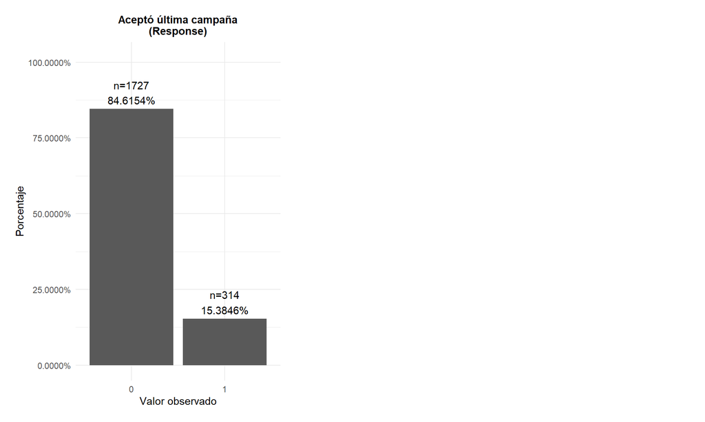

Figure 6.1: Distribución porcentual de las variable target, aceptación de la ultima campaña (Response)

```r
data_temp <- datos_sin_inconsistencia_v1

vars <- c("Response")



plots <- lapply(vars, function(v){

  conteo <- as.data.frame(table(data_temp[[v]], useNA = "ifany"))
  colnames(conteo) <- c("valor", "n")

  conteo$pct <- conteo$n / sum(conteo$n)

  ymax <- max(conteo$pct) * 1.20

  ggplot(conteo, aes(x = factor(valor), y = pct)) +
    geom_col() +
    geom_text(aes(label = paste0("n=", n, "\n", sprintf("%.4f%%", 100*pct))),
              vjust = -0.2, size = 3.8) +
    scale_y_continuous(labels = function(x) sprintf("%.4f%%", 100*x),
                       limits = c(0, ymax)) +
    labs(
      title = stringr::str_wrap(diccionario_vars[[v]], width = 30),
      x = "Valor observado",
      y = "Porcentaje"
    ) +
    theme_minimal() +
    theme(
      plot.title = element_text(size = 11, face = "bold", hjust = 0.5),
      plot.margin = margin(10, 10, 10, 10)
    )
})

wrap_plots(plots, ncol = 3)
```

En la figura 6.1 La variable que tenemos como objetivo a predecir, presenta un desbalance, con una tasa de aceptación del 15.4%. En un modelo toca tener en cuenta que es una clase minoritaria, es analisis es bueno hacerlo con esta proporción debido a que es la proporción real de los datos y tendremos el suspuesto de que esta proporción es representativa para cada categoría. A futuro se debe analizar si el modelo entrenar para la predicción puede ser afectado por este desbalance, por lo general se balancean los datos de entrenamiento, y los de test se mantienen en la distribución real para poder tener métricas más acertadas.

## 6.2 Caracteristicas demograficas y perfil del cliente teniendo en cuenta la última campaña

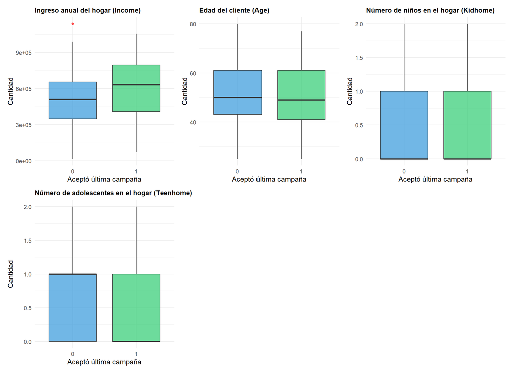

Figure 6.2: Distribución de variables según (Response, 0 = No, 1 = Sí Aceptó última campaña).

```r
data_temp <- datos_finales_sin_errores_ni_inconsistencias

vars_graph <- c("Income",
    "Age",
    "Kidhome",
    "Teenhome")

plots <- lapply(vars_graph, function(v){
  ggplot(data_temp, aes(x = factor(Response), y = .data[[v]], fill = factor(Response))) +
    geom_boxplot(outlier.colour = "red", outlier.shape = 16, outlier.size = 1.5, alpha = 0.7) +
    scale_fill_manual(values = c("#3498db", "#2ecc71")) +
    labs(title = diccionario_vars[[v]],
         x = "Aceptó última campaña",
         y = "Cantidad") +
    theme_minimal() +
    theme(legend.position = "none",
          plot.title = element_text(size = 10, face = "bold"))
})

wrap_plots(plots, ncol = 3)
```

```r
data_temp <- datos_finales_sin_errores_ni_inconsistencias

lista_resultados <- list()
N_TOTAL <- nrow(data_temp)
vars_graph <- c(    "Income",
    "Age",
    "Kidhome",
    "Teenhome")


for(v in vars_graph) {

  # División de datos por target
  g0 <- as.numeric(data_temp[[v]][which(data_temp$Response == 0)])
  g1 <- as.numeric(data_temp[[v]][which(data_temp$Response == 1)])

  procesar <- function(vec, label_cmp) {

    n_total_subgrupo <- length(vec)
    n_na <- sum(is.na(vec))
    pct_na <- (n_na / n_total_subgrupo) * 100

    vec_clean <- na.omit(vec)
    n_subdataset <- length(vec_clean)
    if(n_subdataset == 0) return(NULL)

    # --- Cálculo de Outliers (Regla 1.5 IQR) ---
    q1 <- quantile(vec_clean, 0.25)
    q3 <- quantile(vec_clean, 0.75)
    iqr_val <- q3 - q1
    lim_inf <- q1 - 1.5 * iqr_val
    lim_sup <- q3 + 1.5 * iqr_val

    # Identificar outliers
    outliers <- vec_clean[vec_clean < lim_inf | vec_clean > lim_sup]
    n_outliers <- length(outliers)

    # Porcentajes
    pct_subdataset <- (n_outliers / n_subdataset) * 100
    pct_global <- (n_outliers / N_TOTAL) * 100

    # --- Generación de estadísticos con summarytools ---
    descr(vec_clean,
          stats = c("n.valid","min","q1","med","q3","max","mean","sd","cv"),
          transpose = TRUE) %>%
      tb() %>%
      rename(Estadistico = 1) %>%
      mutate(
        Variable = v,
        Response = label_cmp,
        Outliers_N = n_outliers,
        `Pct_Outlier_Subgrupo` = pct_subdataset,
        `Pct_Outlier_Global` = pct_global,
        Datos_NA = n_na,
        Pct_Datos_NA = pct_na
      )
  }

  lista_resultados[[paste0(v, "_0")]] <- procesar(g0, 0)
  lista_resultados[[paste0(v, "_1")]] <- procesar(g1, 1)
}

# 2. Unir resultados en una sola tabla
tabla_maestra <- bind_rows(lista_resultados) %>%
  select(Variable, everything(), -Estadistico, Outliers_N, `Pct_Outlier_Subgrupo`, `Pct_Outlier_Global`) %>%
  mutate(
    Variable = str_trim(as.character(Variable)),
    Variable = ifelse(
      Variable %in% names(diccionario_vars),
      unname(diccionario_vars[Variable]),
      Variable
    )
  )

knitr::kable(tabla_maestra,
             digits = 2,
             caption = "Análisis de Variables y Outliers (1.5*IQR) por Campaña",
             format = "html") %>%   kable_styling(bootstrap_options = c("bordered", "striped", "hover"), full_width = F, font_size = 11) %>% scroll_box(width = "700px")
```

Table 6.1: Análisis de Variables y Outliers (1.5*IQR) por Campaña

| Variable | n.valid | min | q1 | med | q3 | max | mean | sd | cv | Response | Outliers_N | Pct_Outlier_Subgrupo | Pct_Outlier_Global | Datos_NA | Pct_Datos_NA |
| --- | --- | --- | --- | --- | --- | --- | --- | --- | --- | --- | --- | --- | --- | --- | --- |
| Ingreso anual del hogar (Income) | 1726 | 17300 | 349160 | 511715 | 654860 | 1137340 | 502062.33 | 195264.25 | 0.39 | 0 | 1 | 0.06 | 0.05 | 0 | 0 |
| Ingreso anual del hogar (Income) | 313 | 75000 | 408870 | 632110 | 796070 | 1054710 | 600820.03 | 227138.99 | 0.38 | 1 | 0 | 0.00 | 0.00 | 0 | 0 |
| Edad del cliente (Age) | 1726 | 25 | 43 | 50 | 61 | 80 | 51.29 | 11.51 | 0.22 | 0 | 0 | 0.00 | 0.00 | 0 | 0 |
| Edad del cliente (Age) | 313 | 25 | 41 | 49 | 61 | 77 | 50.51 | 12.29 | 0.24 | 1 | 0 | 0.00 | 0.00 | 0 | 0 |
| Número de niños en el hogar (Kidhome) | 1726 | 0 | 0 | 0 | 1 | 2 | 0.46 | 0.54 | 1.18 | 0 | 0 | 0.00 | 0.00 | 0 | 0 |
| Número de niños en el hogar (Kidhome) | 313 | 0 | 0 | 0 | 1 | 2 | 0.34 | 0.49 | 1.44 | 1 | 0 | 0.00 | 0.00 | 0 | 0 |
| Número de adolescentes en el hogar (Teenhome) | 1726 | 0 | 0 | 1 | 1 | 2 | 0.54 | 0.55 | 1.01 | 0 | 0 | 0.00 | 0.00 | 0 | 0 |
| Número de adolescentes en el hogar (Teenhome) | 313 | 0 | 0 | 0 | 1 | 2 | 0.31 | 0.50 | 1.62 | 1 | 0 | 0.00 | 0.00 | 0 | 0 |

Viendo la 6.2 y la Tabla 6.1 se observa que:

- Ingreso anual del hogar (Income) tiene una diferencia entre quienes aceptan y no aceptan ️la última campaña,los que aceptan tienen mayor ingreso. Es una variable predictora potencial.
- Edad del cliente (Age) No hay separación real entre grupos. No se observa patrón diferencial fuerte. No es una variable predictora potencial.
- Número de niños en el hogar (Kidhome) tiene una diferencia pequeña podría indicar que hogares con menos niños aceptan un poco más, pero la señal es débil. Es una variable predictora bajamente potencial.
- Número de adolescentes en el hogar (Teenhome) Clientes con más adolescentes parecen aceptar menos, hay señal más clara que en Kidhome. Es una variable predictora medianamente potencial.